# Stock Returns

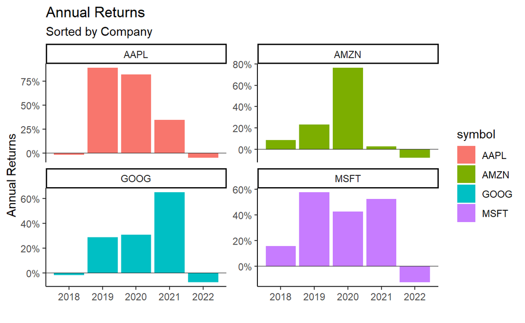

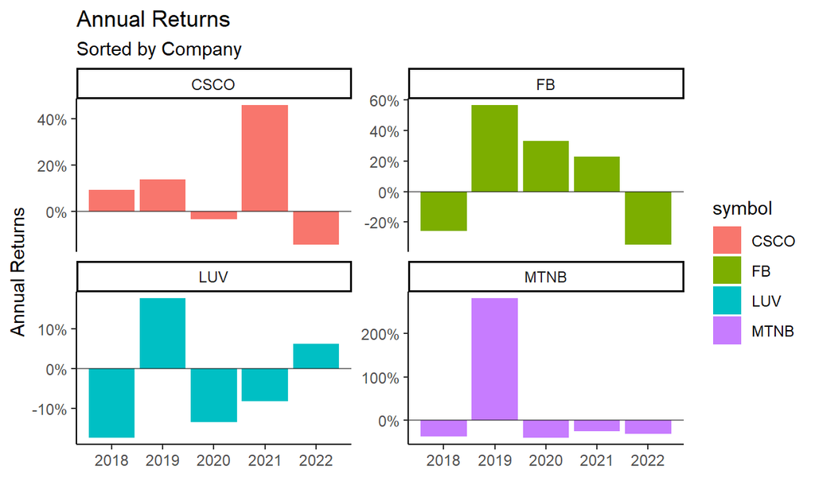

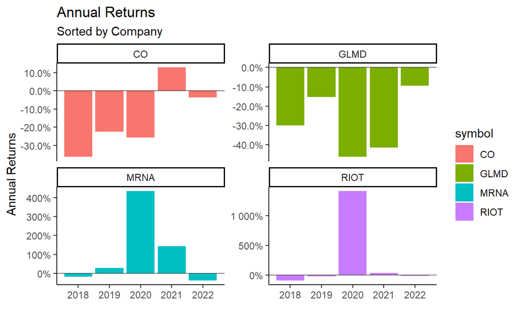

```r
for (stock_group in Stock_block){
x <- yearlyReturns%>%
    filter(symbol %in% stock_group)%>%
  ggplot()+
  geom_col(aes(x = Year, y = yearly.returns, fill = symbol))+
  geom_hline(yintercept = 0, alpha = .5)+
  scale_y_continuous(labels = scales::percent)+
  labs(title = "Annual Returns",
       subtitle = "Sorted by Company",
       y = "Annual Returns", x = "")+
  facet_wrap(~symbol, ncol = 2, scales = "free_y")+
  theme_classic()
print(x)
}
```

# Final look

The last attempt I will use to observe the stocks is based on the price trends. Using the for loop and stock groups I will facet through the stocks 4 at a time and compare the prices. It can be seen from below that even when using free scale, or not using free scale, theres no easy way to compare stocks with such different price differences.

To come up with a way to fix this, I decided to normalize the prices themselves.

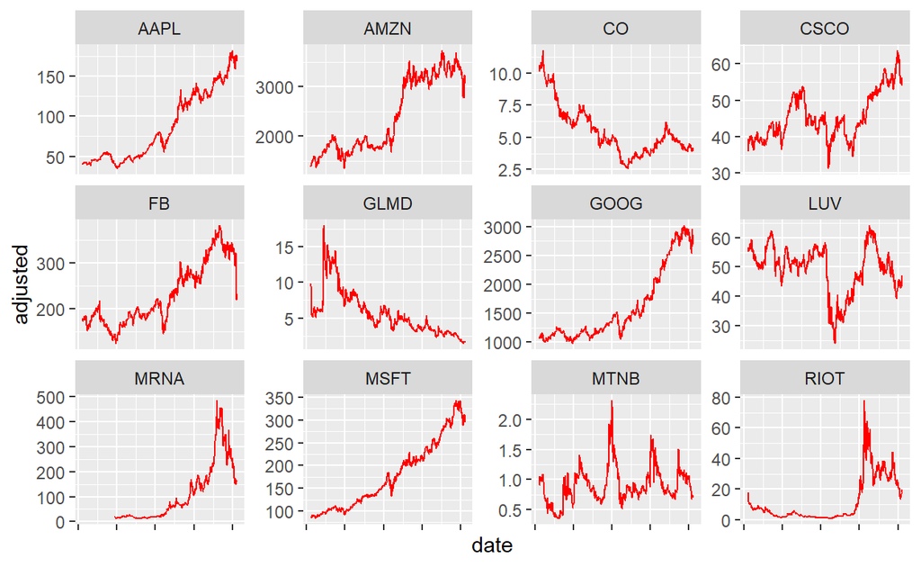

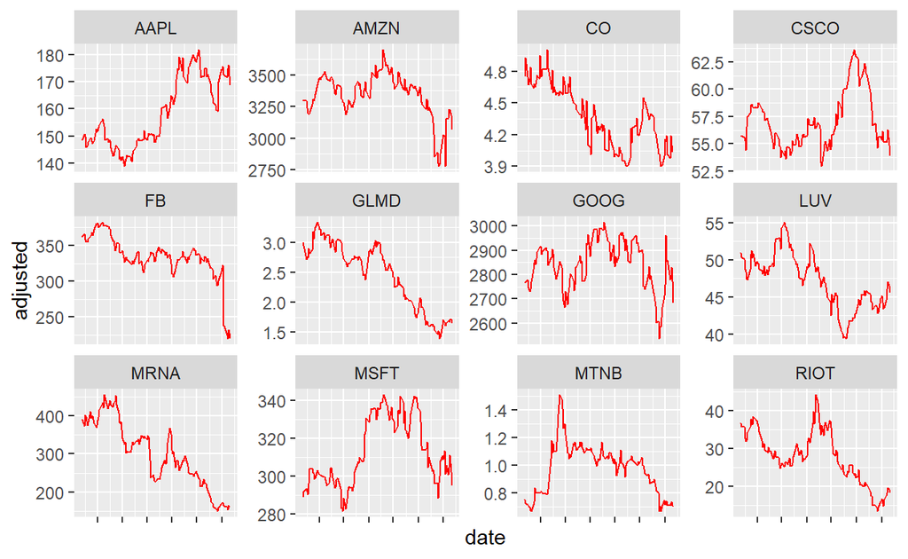

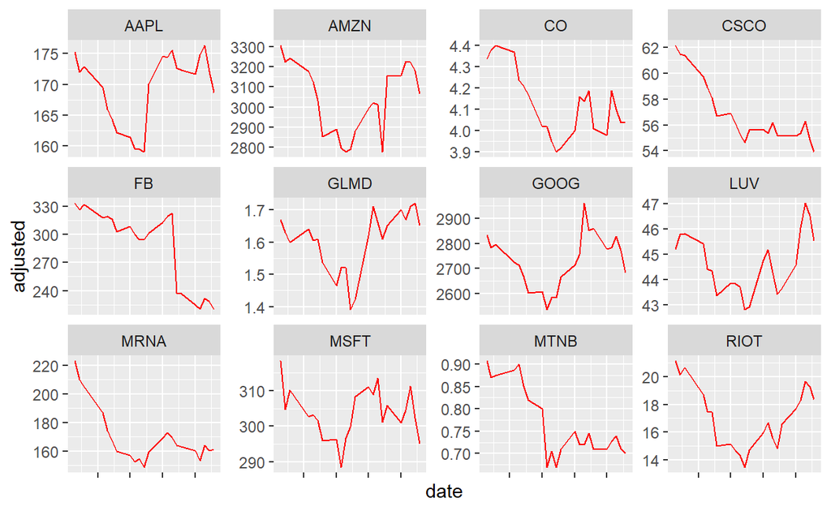

```r
multiple_dates <- rev(list(month1_date, month6_date, Year_4_date))


for (dates in multiple_dates){
print(data %>%
   filter(date >= dates)%>%
  ggplot()+
  geom_line(aes(x = date, y = adjusted),color = "red")+
  facet_wrap(~symbol, scales = "free_y")+
    theme(axis.text.x = element_blank()))
}
```

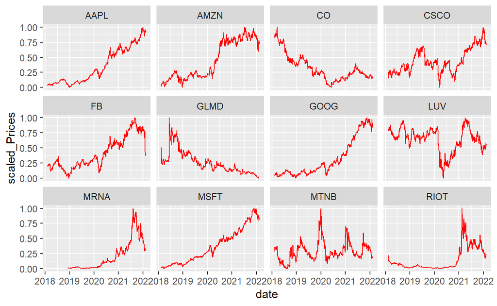

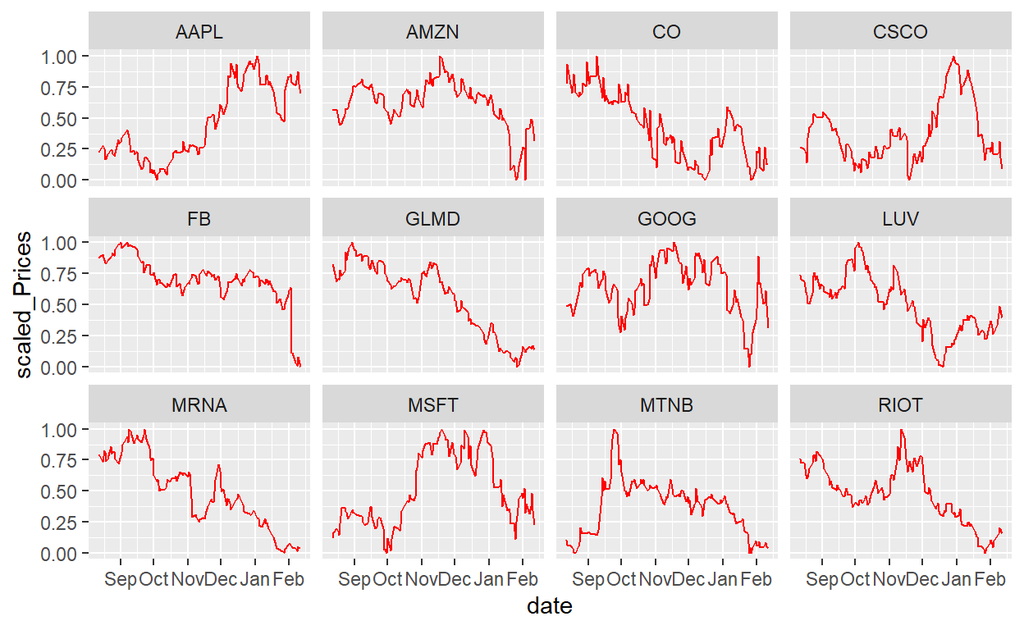

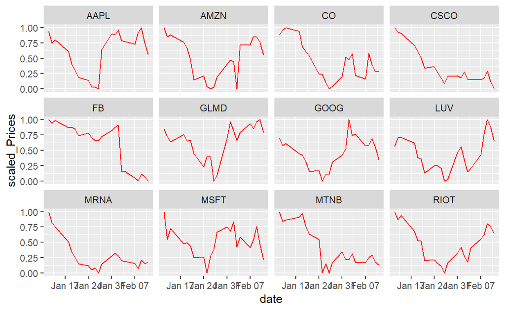

```r
normalize_funciton <- function(x){
  return((x - min(x))/(max(x)- min(x)))
}

for (dates in multiple_dates){
print(data %>%
        filter(date >= dates)%>%
 group_by(symbol)%>%
  mutate(scaled_Prices = normalize_funciton(adjusted))%>%
   ggplot()+
  geom_line(aes(x = date, y = scaled_Prices),color = "red")+
  facet_wrap(~symbol))

}
```

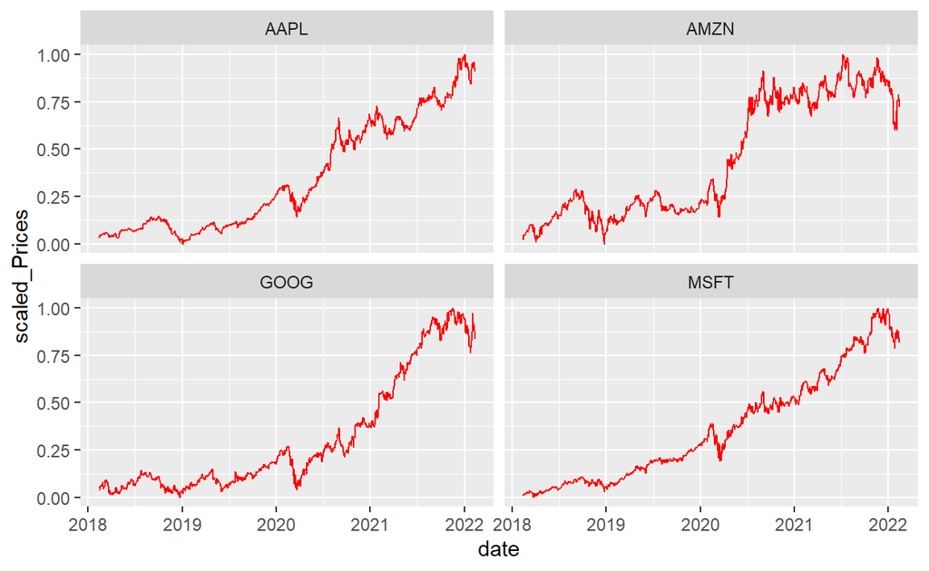

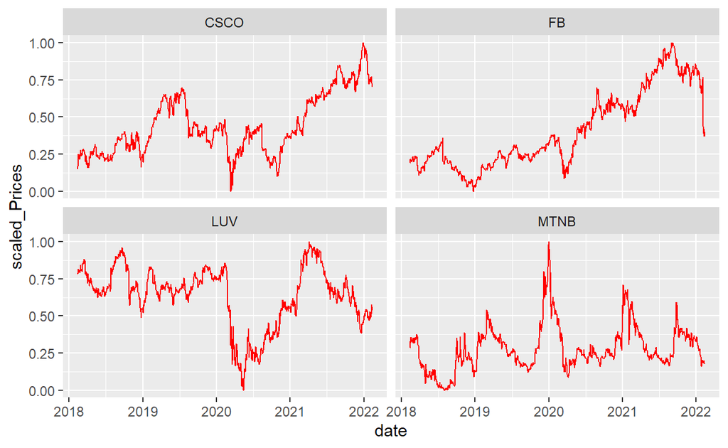

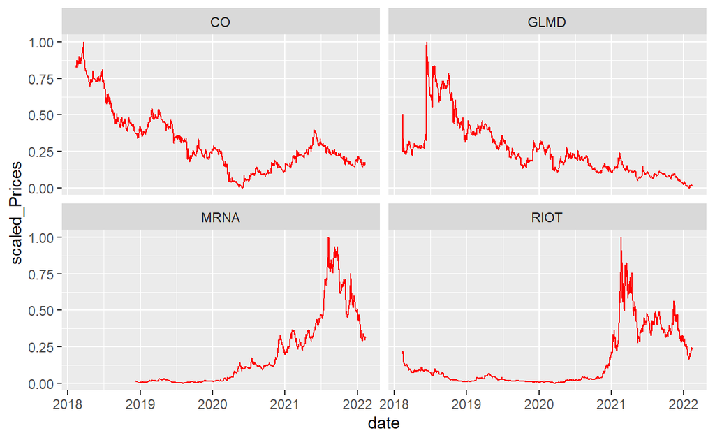

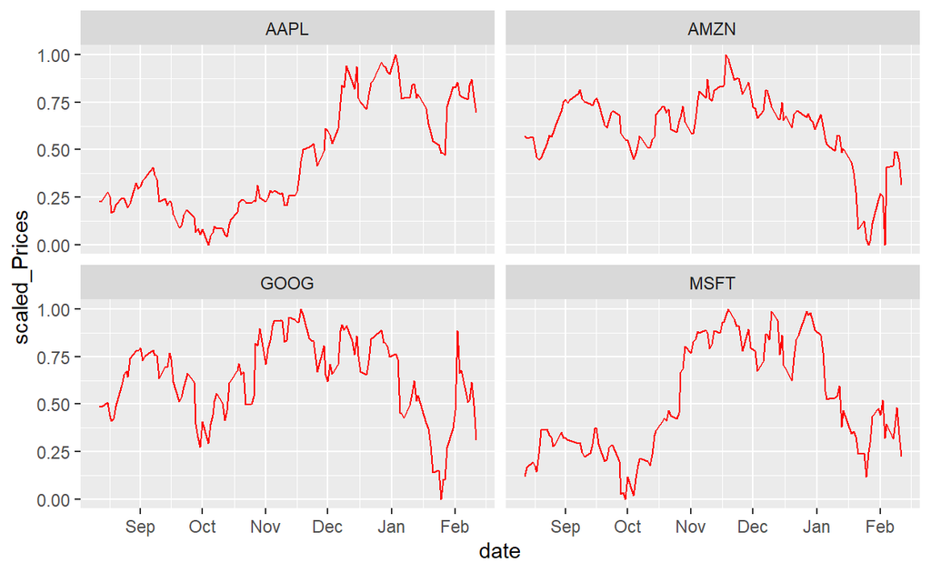

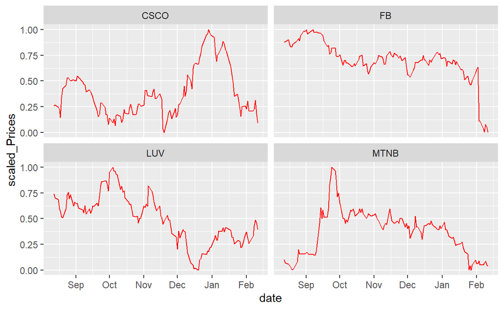

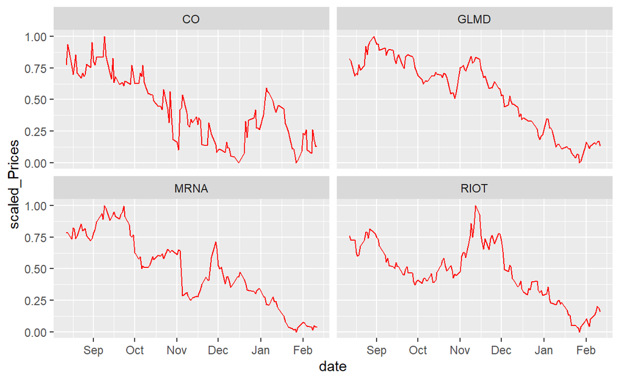

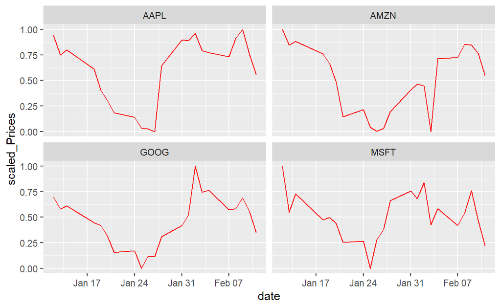

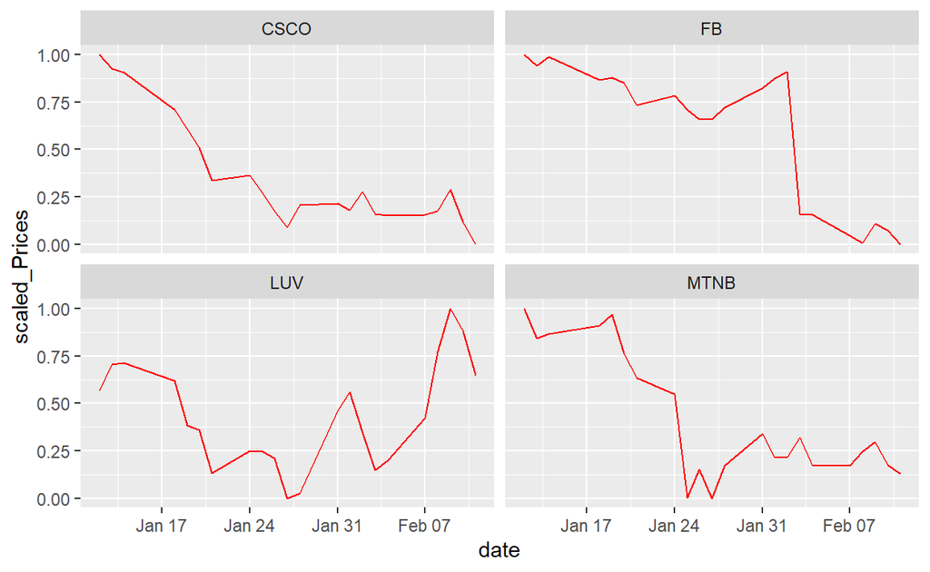

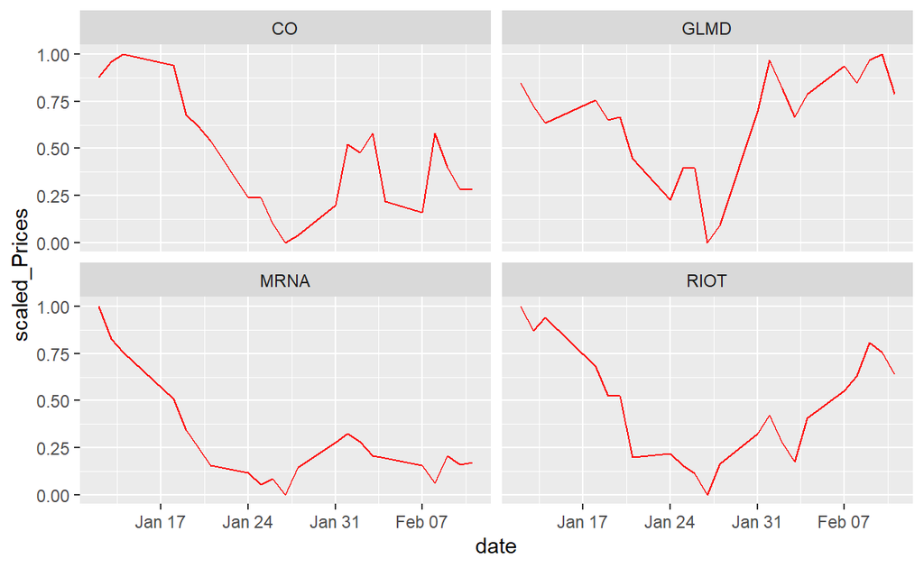

```r
for (dates in multiple_dates){
for (stock_group in Stock_block){
print(data %>%
        filter(date >= dates)%>%
        filter(symbol %in% stock_group)%>%
 group_by(symbol)%>%
  mutate(scaled_Prices = normalize_funciton(adjusted))%>%
   ggplot()+
  geom_line(aes(x = date, y = scaled_Prices),color = "red")+
  facet_wrap(~symbol))

}
}
```

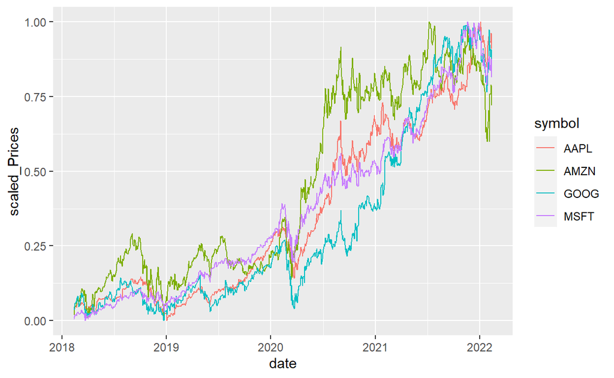

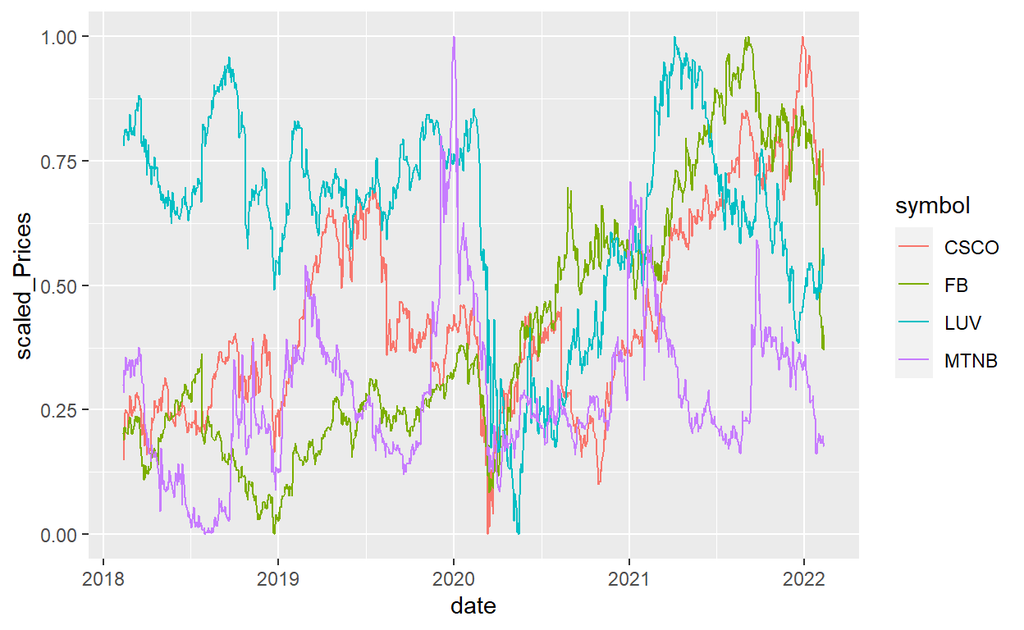

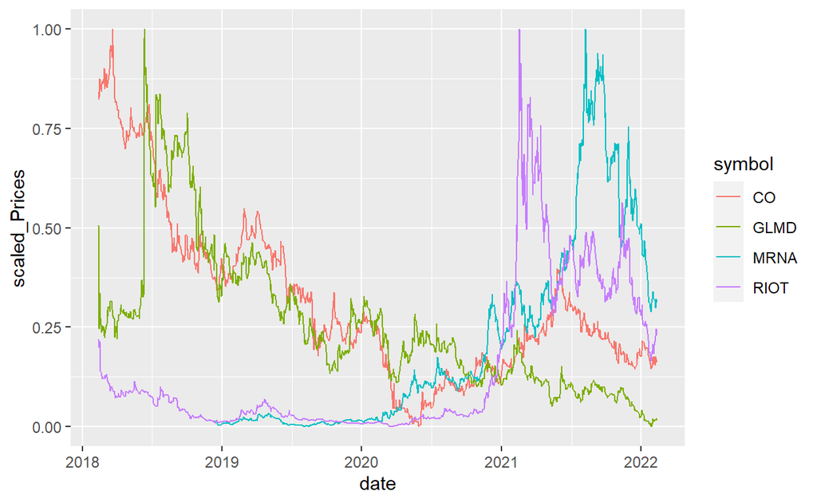

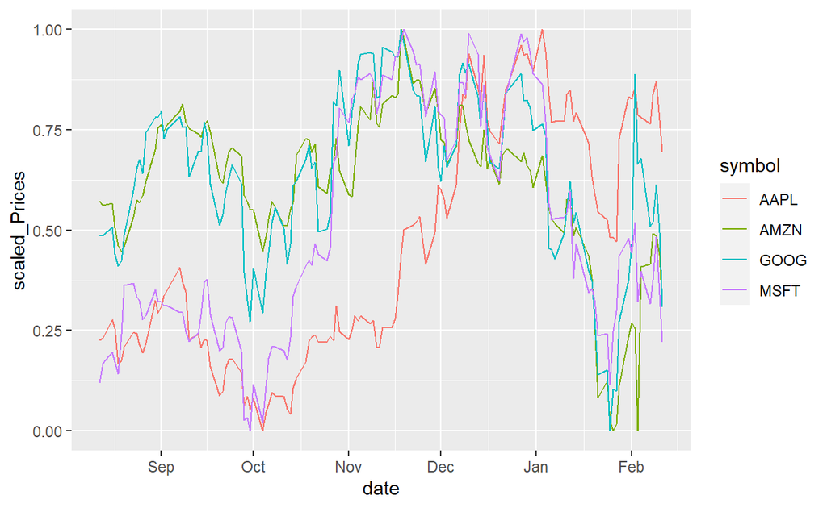

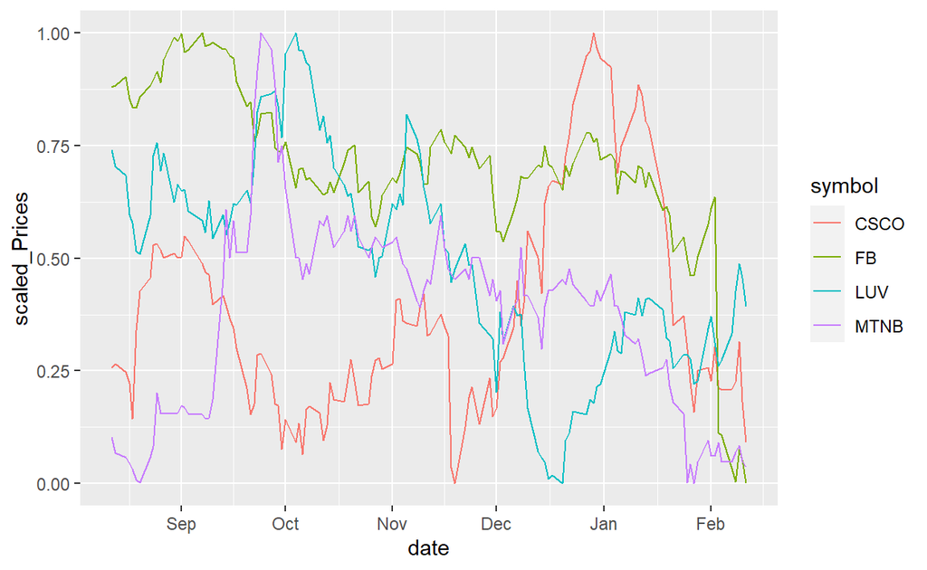

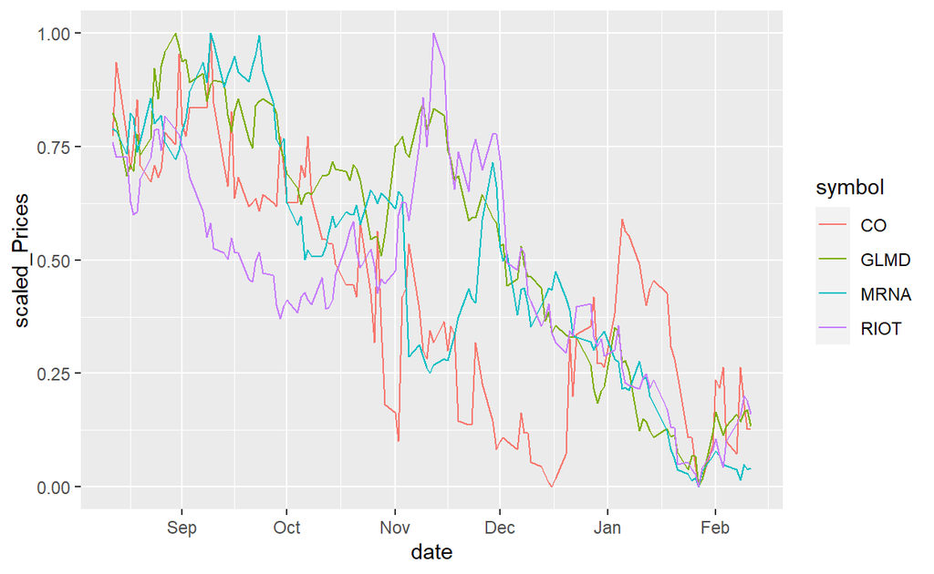

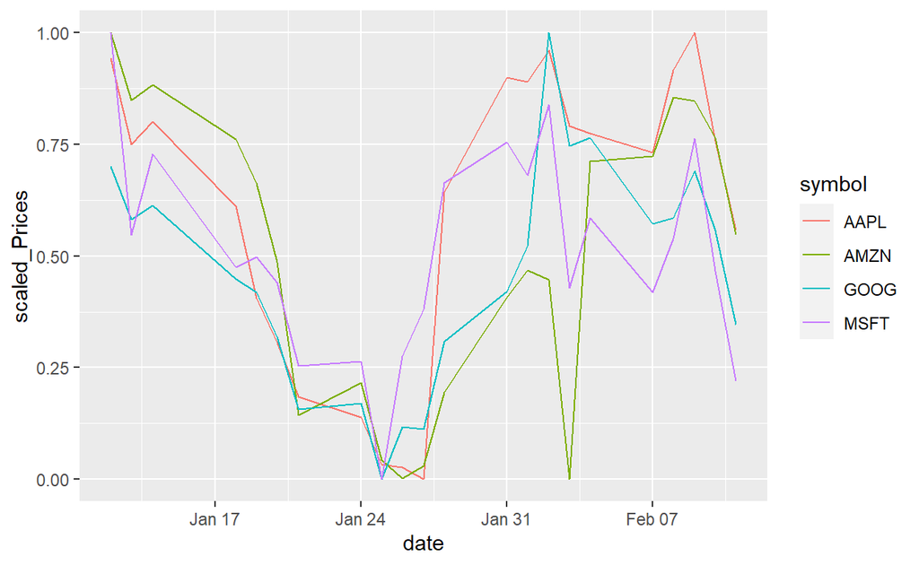

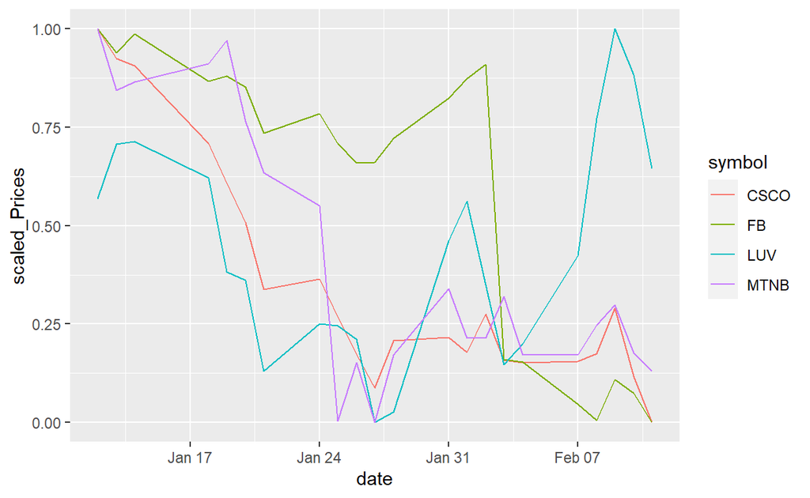

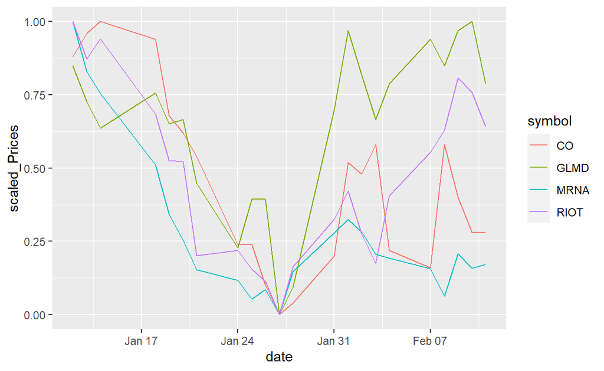

```r
for (dates in multiple_dates){
   for (stock_group in Stock_block){
print(data %>%
  filter(date >= dates)%>%
    filter(symbol %in% stock_group)%>%
  group_by(symbol)%>%
  mutate(scaled_Prices = normalize_funciton(adjusted))%>%
  ggplot()+
  geom_line(aes(x = date, y =scaled_Prices, color = symbol)))
}

}
```